# Tutorial Básico de R

Claude

2025-11-13

# 1 Introducción a R Base

R es un lenguaje poderoso para análisis estadístico y ciencia de datos. En este tutorial aprenderemos los **fundamentos de R** usando solo las funciones que vienen incluidas en la instalación base, sin necesidad de instalar paquetes adicionales.

## 1.1 ¿Qué aprenderás?

- Tipos de datos básicos en R
- Operaciones con vectores, listas y data frames
- Funciones básicas para análisis estadístico
- Manipulación de datos con R base
- Creación de gráficos básicos
- Control de flujo (if, for, while)
- Funciones personalizadas

# 2 Tipos de Datos Básicos

R maneja varios tipos de datos fundamentales. Vamos a explorarlos uno por uno.

## 2.1 Vectores

Los vectores son la estructura de datos más básica en R.

```r
# Vectores numéricos
numeros <- c(1, 2, 3, 4, 5)
c(1, 2, 3, 4, 5) -> numeros2
numeros3 = c(1, 2, 3, 4, 5)
print("Vector numérico:")
```

```
## [1] "Vector numérico:"
```

```r
print(numeros)
```

```
## [1] 1 2 3 4 5
```

```r
# Vectores de caracteres (strings)
nombres <- c("Ana", "Carlos", "María", "Pedro", "Laura")
print("Vector de caracteres:")
```

```
## [1] "Vector de caracteres:"
```

```r
print(nombres)
```

```
## [1] "Ana"    "Carlos" "María"  "Pedro"  "Laura"
```

```r
# Vectores lógicos
logicos <- c(TRUE, FALSE, TRUE, TRUE, FALSE)
print("Vector lógico:")
```

```
## [1] "Vector lógico:"
```

```r
print(logicos)
```

```
## [1]  TRUE FALSE  TRUE  TRUE FALSE
```

```r
# Secuencias
secuencia1 <- 1:10
secuencia2 <- seq(0, 100, by = 10)
print("Secuencias:")
```

```
## [1] "Secuencias:"
```

```r
print(secuencia1)
```

```
##  [1]  1  2  3  4  5  6  7  8  9 10
```

```r
print(secuencia2)
```

```
##  [1]   0  10  20  30  40  50  60  70  80  90 100
```

## 2.2 Ejemplo de Calculo

```r
set.seed(123)
errores = 100 * runif(n=100)
rmse = sqrt(mean(errores**2))
mse = mean(errores**2)
print(errores)
```

```
##   [1] 28.75775201 78.83051354 40.89769218 88.30174040 94.04672843  4.55564994
##   [7] 52.81054880 89.24190444 55.14350145 45.66147353 95.68333453 45.33341562
##  [13] 67.75706355 57.26334020 10.29246827 89.98249704 24.60877344  4.20595335
##  [19] 32.79207193 95.45036491 88.95393161 69.28034062 64.05068138 99.42697766
##  [25] 65.57057991 70.85304682 54.40660247 59.41420204 28.91597373 14.71136473
##  [31] 96.30242325 90.22990451 69.07052784 79.54674177  2.46136845 47.77959711
##  [37] 75.84595375 21.64079358 31.81810076 23.16257854 14.28000224 41.45463358
##  [43] 41.37243263 36.88454509 15.24447477 13.88060634 23.30340995 46.59624503
##  [49] 26.59726404 85.78277153  4.58311667 44.22000742 79.89248456 12.18992600
##  [55] 56.09479838 20.65313896 12.75316502 75.33078643 89.50453592 37.44627759
##  [61] 66.51151946  9.48406609 38.39696378 27.43836446 81.46400389 44.85163414
##  [67] 81.00643530 81.23895095 79.43423211 43.98316876 75.44751586 62.92211316
##  [73] 71.01824014  0.06247733 47.53165741 22.01188852 37.98165377 61.27710033
##  [79] 35.17979092 11.11354243 24.36194727 66.80555874 41.76467797 78.81958340
##  [85] 10.28646443 43.48927415 98.49569800 89.30511144 88.64690608 17.50526503
##  [91] 13.06956916 65.31019250 34.35164723 65.67581280 32.03732425 18.76911193
##  [97] 78.22943013  9.35949867 46.67790416 51.15054599
```

```r
print(rmse)
```

```
## [1] 57.35601
```

```r
print(mse)
```

```
## [1] 3289.712
```

## 2.3 Operaciones básicas con vectores

```r
# Operaciones matemáticas
precios <- c(100, 250, 75, 300, 150)
print("Precios originales:")
```

```
## [1] "Precios originales:"
```

```r
print(precios)
```

```
## [1] 100 250  75 300 150
```

```r
# Aplicar descuento del 10%
precios_descuento <- precios * 0.9
print("Precios con descuento:")
```

```
## [1] "Precios con descuento:"
```

```r
print(precios_descuento)
```

```
## [1]  90.0 225.0  67.5 270.0 135.0
```

```r
# Sumar un valor fijo
precios_con_iva <- precios_descuento * 1.21
print("Precios con IVA:")
```

```
## [1] "Precios con IVA:"
```

```r
print(precios_con_iva)
```

```
## [1] 108.900 272.250  81.675 326.700 163.350
```

```r
# Estadísticas básicas
print(paste("Precio promedio:", mean(precios)))
```

```
## [1] "Precio promedio: 175"
```

```r
print(paste("Precio mínimo:", min(precios)))
```

```
## [1] "Precio mínimo: 75"
```

```r
print(paste("Precio máximo:", max(precios)))
```

```
## [1] "Precio máximo: 300"
```

```r
print(paste("Suma total:", sum(precios)))
```

```
## [1] "Suma total: 875"
```

## 2.4 Indexación de vectores

```r
# Acceso por posición
productos <- c("Laptop", "Mouse", "Teclado", "Monitor", "Auriculares")

print("Primer producto:")
```

```
## [1] "Primer producto:"
```

```r
print(productos[1])
```

```
## [1] "Laptop"
```

```r
print("Productos 2 al 4:")
```

```
## [1] "Productos 2 al 4:"
```

```r
print(productos[2:4])
```

```
## [1] "Mouse"   "Teclado" "Monitor"
```

```r
print("Productos seleccionados:")
```

```
## [1] "Productos seleccionados:"
```

```r
print(productos[c(1, 3, 5)])
```

```
## [1] "Laptop"      "Teclado"     "Auriculares"
```

```r
# Acceso por condición
ventas_dia <- c(120, 80, 200, 50, 300)
print("Ventas mayores a 100:")
```

```
## [1] "Ventas mayores a 100:"
```

```r
print(ventas_dia[ventas_dia > 100])
```

```
## [1] 120 200 300
```

```r
# Nombres de elementos
names(ventas_dia) <- productos
print("Ventas por producto:")
```

```
## [1] "Ventas por producto:"
```

```r
print(ventas_dia)
```

```
##      Laptop       Mouse     Teclado     Monitor Auriculares
##         120          80         200          50         300
```

# 3 Listas y Data Frames

## 3.1 Listas

Las listas pueden contener diferentes tipos de datos.

```r
# Crear una lista
empleado <- list(
  nombre = "Ana García",
  edad = 28,
  salario = 45000,
  activo = TRUE,
  departamentos = c("Ventas", "Marketing")
)

print("Información del empleado:")
```

```
## [1] "Información del empleado:"
```

```r
print(empleado)
```

```
## $nombre
## [1] "Ana García"
##
## $edad
## [1] 28
##
## $salario
## [1] 45000
##
## $activo
## [1] TRUE
##
## $departamentos
## [1] "Ventas"    "Marketing"
```

```r
# Acceso a elementos de la lista
print(paste("Nombre:", empleado$nombre))
```

```
## [1] "Nombre: Ana García"
```

```r
print(paste("Edad:", empleado[["edad"]]))
```

```
## [1] "Edad: 28"
```

```r
print("Departamentos:")
```

```
## [1] "Departamentos:"
```

```r
print(empleado$departamentos)
```

```
## [1] "Ventas"    "Marketing"
```

## 3.2 Data Frames

Los data frames son la estructura principal para datos tabulares.

```r
# Crear un data frame
set.seed(123)  # Para reproducibilidad

# Crear datos de ejemplo
empleados <- data.frame(
  nombre = c("Ana", "Carlos", "María", "Pedro", "Laura"),
  edad = c(28, 35, 42, 29, 38),
  salario = c(45000, 52000, 48000, 41000, 55000),
  departamento = c("Ventas", "IT", "RRHH", "Ventas", "IT"),
  activo = c(TRUE, TRUE, FALSE, TRUE, TRUE),
  stringsAsFactors = FALSE
)

print("Data frame de empleados:")
```

```
## [1] "Data frame de empleados:"
```

```r
print(empleados)
```

```
##   nombre edad salario departamento activo
## 1    Ana   28   45000       Ventas   TRUE
## 2 Carlos   35   52000           IT   TRUE
## 3  María   42   48000         RRHH  FALSE
## 4  Pedro   29   41000       Ventas   TRUE
## 5  Laura   38   55000           IT   TRUE
```

```r
# Información del data frame
print("Estructura del data frame:")
```

```
## [1] "Estructura del data frame:"
```

```r
str(empleados)
```

```
## 'data.frame':    5 obs. of  5 variables:
##  $ nombre      : chr  "Ana" "Carlos" "María" "Pedro" ...
##  $ edad        : num  28 35 42 29 38
##  $ salario     : num  45000 52000 48000 41000 55000
##  $ departamento: chr  "Ventas" "IT" "RRHH" "Ventas" ...
##  $ activo      : logi  TRUE TRUE FALSE TRUE TRUE
```

```r
print("Dimensiones:")
```

```
## [1] "Dimensiones:"
```

```r
print(paste("Filas:", nrow(empleados)))
```

```
## [1] "Filas: 5"
```

```r
print(paste("Columnas:", ncol(empleados)))
```

```
## [1] "Columnas: 5"
```

```r
# Primeras y últimas filas
print("Primeras 3 filas:")
```

```
## [1] "Primeras 3 filas:"
```

```r
head(empleados, 3)
```

```
##   nombre edad salario departamento activo
## 1    Ana   28   45000       Ventas   TRUE
## 2 Carlos   35   52000           IT   TRUE
## 3  María   42   48000         RRHH  FALSE
```

```r
print("Últimas 2 filas:")
```

```
## [1] "Últimas 2 filas:"
```

```r
tail(empleados, 2)
```

```
##   nombre edad salario departamento activo
## 4  Pedro   29   41000       Ventas   TRUE
## 5  Laura   38   55000           IT   TRUE
```

# 4 Manipulación de Data Frames

## 4.1 Selección de datos

```r
# Seleccionar columnas
print("Solo nombres y salarios:")
```

```
## [1] "Solo nombres y salarios:"
```

```r
print(empleados[, c("nombre", "salario")])
```

```
##   nombre salario
## 1    Ana   45000
## 2 Carlos   52000
## 3  María   48000
## 4  Pedro   41000
## 5  Laura   55000
```

```r
# Seleccionar filas
print("Empleados activos:")
```

```
## [1] "Empleados activos:"
```

```r
empleados_activos <- empleados[empleados$activo == TRUE, ]
print(empleados_activos)
```

```
##   nombre edad salario departamento activo
## 1    Ana   28   45000       Ventas   TRUE
## 2 Carlos   35   52000           IT   TRUE
## 4  Pedro   29   41000       Ventas   TRUE
## 5  Laura   38   55000           IT   TRUE
```

```r
print("Empleados de IT:")
```

```
## [1] "Empleados de IT:"
```

```r
empleados_it <- empleados[empleados$departamento == "IT", ]
print(empleados_it)
```

```
##   nombre edad salario departamento activo
## 2 Carlos   35   52000           IT   TRUE
## 5  Laura   38   55000           IT   TRUE
```

```r
print("Empleados con salario mayor a 45000:")
```

```
## [1] "Empleados con salario mayor a 45000:"
```

```r
salarios_altos <- empleados[empleados$salario > 45000, ]
print(salarios_altos[, c("nombre", "salario")])
```

```
##   nombre salario
## 2 Carlos   52000
## 3  María   48000
## 5  Laura   55000
```

## 4.2 Agregar y modificar datos

```r
# Agregar una nueva columna
empleados$bonus <- empleados$salario * 0.1
print("Data frame con bonus:")
```

```
## [1] "Data frame con bonus:"
```

```r
print(empleados[, c("nombre", "salario", "bonus")])
```

```
##   nombre salario bonus
## 1    Ana   45000  4500
## 2 Carlos   52000  5200
## 3  María   48000  4800
## 4  Pedro   41000  4100
## 5  Laura   55000  5500
```

```r
# Modificar valores
empleados$salario[empleados$departamento == "IT"] <- empleados$salario[empleados$departamento == "IT"] * 1.05
print("Salarios después del aumento para IT:")
```

```
## [1] "Salarios después del aumento para IT:"
```

```r
print(empleados[, c("nombre", "departamento", "salario")])
```

```
##   nombre departamento salario
## 1    Ana       Ventas   45000
## 2 Carlos           IT   54600
## 3  María         RRHH   48000
## 4  Pedro       Ventas   41000
## 5  Laura           IT   57750
```

```r
# Agregar una nueva fila
nuevo_empleado <- data.frame(
  nombre = "Roberto",
  edad = 31,
  salario = 47000,
  departamento = "Finanzas",
  activo = TRUE,
  bonus = 4700
)

empleados <- rbind(empleados, nuevo_empleado)
print("Data frame con nuevo empleado:")
```

```
## [1] "Data frame con nuevo empleado:"
```

```r
print(empleados)
```

```
##    nombre edad salario departamento activo bonus
## 1     Ana   28   45000       Ventas   TRUE  4500
## 2  Carlos   35   54600           IT   TRUE  5200
## 3   María   42   48000         RRHH  FALSE  4800
## 4   Pedro   29   41000       Ventas   TRUE  4100
## 5   Laura   38   57750           IT   TRUE  5500
## 6 Roberto   31   47000     Finanzas   TRUE  4700
```

# 5 Funciones Estadísticas Básicas

## 5.1 Estadísticas descriptivas

```r
# Trabajar con los salarios
salarios <- empleados$salario

print("Estadísticas descriptivas de salarios:")
```

```
## [1] "Estadísticas descriptivas de salarios:"
```

```r
print(paste("Media:", round(mean(salarios), 2)))
```

```
## [1] "Media: 48891.67"
```

```r
print(paste("Mediana:", median(salarios)))
```

```
## [1] "Mediana: 47500"
```

```r
print(paste("Desviación estándar:", round(sd(salarios), 2)))
```

```
## [1] "Desviación estándar: 6210.51"
```

```r
print(paste("Varianza:", round(var(salarios), 2)))
```

```
## [1] "Varianza: 38570416.67"
```

```r
print(paste("Rango:", paste(min(salarios), "-", max(salarios))))
```

```
## [1] "Rango: 41000 - 57750"
```

```r
# Cuartiles
print("Resumen de cinco números:")
```

```
## [1] "Resumen de cinco números:"
```

```r
print(summary(salarios))
```

```
##    Min. 1st Qu.  Median    Mean 3rd Qu.    Max.
##   41000   45500   47500   48892   52950   57750
```

```r
# Cuantiles específicos
print("Cuantiles:")
```

```
## [1] "Cuantiles:"
```

```r
print(quantile(salarios, c(0.25, 0.5, 0.75, 0.9)))
```

```
##   25%   50%   75%   90%
## 45500 47500 52950 56175
```

## 5.2 Análisis por grupos

```r
# Análisis por departamento usando funciones base
departamentos_unicos <- unique(empleados$departamento)

print("Análisis por departamento:")
```

```
## [1] "Análisis por departamento:"
```

```r
for (dept in departamentos_unicos) {
  dept_data <- empleados[empleados$departamento == dept, ]
  cat("\n--- Departamento:", dept, "---\n")
  cat("Número de empleados:", nrow(dept_data), "\n")
  cat("Salario promedio:", round(mean(dept_data$salario), 2), "\n")
  cat("Edad promedio:", round(mean(dept_data$edad), 2), "\n")
}
```

```
##
## --- Departamento: Ventas ---
## Número de empleados: 2
## Salario promedio: 43000
## Edad promedio: 28.5
##
## --- Departamento: IT ---
## Número de empleados: 2
## Salario promedio: 56175
## Edad promedio: 36.5
##
## --- Departamento: RRHH ---
## Número de empleados: 1
## Salario promedio: 48000
## Edad promedio: 42
##
## --- Departamento: Finanzas ---
## Número de empleados: 1
## Salario promedio: 47000
## Edad promedio: 31
```

```r
# Tabla de contingencia
print("\nTabla de contingencia - Departamento vs Estado:")
```

```
## [1] "\nTabla de contingencia - Departamento vs Estado:"
```

```r
tabla_contingencia <- table(empleados$departamento, empleados$activo)
print(tabla_contingencia)
```

```
##
##            FALSE TRUE
##   Finanzas     0    1
##   IT           0    2
##   RRHH         1    0
##   Ventas       0    2
```

# 6 Funciones de Agregación

## 6.1 Funciones apply

```r
# Crear una matriz para demostrar apply
set.seed(456)
ventas_matriz <- matrix(runif(20, 100, 1000), nrow = 4, ncol = 5)
rownames(ventas_matriz) <- c("Ene", "Feb", "Mar", "Abr")
colnames(ventas_matriz) <- c("Producto_A", "Producto_B", "Producto_C", "Producto_D", "Producto_E")

print("Matriz de ventas mensuales:")
```

```
## [1] "Matriz de ventas mensuales:"
```

```r
print(round(ventas_matriz, 2))
```

```
##     Producto_A Producto_B Producto_C Producto_D Producto_E
## Ene     180.60     809.56     313.75     779.59     858.81
## Feb     289.46     398.76     446.71     839.51     507.91
## Mar     759.66     174.19     435.65     639.03     745.08
## Abr     866.92     356.97     296.12     685.93     362.10
```

```r
# Apply por filas (meses)
print("Ventas totales por mes:")
```

```
## [1] "Ventas totales por mes:"
```

```r
ventas_mes <- apply(ventas_matriz, 1, sum)
print(round(ventas_mes, 2))
```

```
##     Ene     Feb     Mar     Abr
## 2942.31 2482.36 2753.61 2568.04
```

```r
# Apply por columnas (productos)
print("Ventas totales por producto:")
```

```
## [1] "Ventas totales por producto:"
```

```r
ventas_producto <- apply(ventas_matriz, 2, sum)
print(round(ventas_producto, 2))
```

```
## Producto_A Producto_B Producto_C Producto_D Producto_E
##    2096.64    1739.49    1492.23    2944.06    2473.90
```

```r
# Apply con otras funciones
print("Promedio por producto:")
```

```
## [1] "Promedio por producto:"
```

```r
promedio_producto <- apply(ventas_matriz, 2, mean)
print(round(promedio_producto, 2))
```

```
## Producto_A Producto_B Producto_C Producto_D Producto_E
##     524.16     434.87     373.06     736.02     618.48
```

## 6.2 Funciones tapply, lapply, sapply

```r
# tapply - aplicar función por grupos
print("Salario promedio por departamento usando tapply:")
```

```
## [1] "Salario promedio por departamento usando tapply:"
```

```r
salario_por_dept <- tapply(empleados$salario, empleados$departamento, mean)
print(round(salario_por_dept, 2))
```

```
## Finanzas       IT     RRHH   Ventas
##    47000    56175    48000    43000
```

```r
# lapply - aplicar función a listas
numeros_lista <- list(a = 1:5, b = 6:10, c = 11:15)
print("Suma de cada elemento de la lista:")
```

```
## [1] "Suma de cada elemento de la lista:"
```

```r
sumas <- lapply(numeros_lista, sum)
print(sumas)
```

```
## $a
## [1] 15
##
## $b
## [1] 40
##
## $c
## [1] 65
```

```r
# sapply - versión simplificada de lapply
print("Promedio de cada elemento (usando sapply):")
```

```
## [1] "Promedio de cada elemento (usando sapply):"
```

```r
promedios <- sapply(numeros_lista, mean)
print(promedios)
```

```
##  a  b  c
##  3  8 13
```

# 7 Control de Flujo

## 7.1 Condicionales (if/else)

```r
# Función para categorizar salarios
categorizar_salario <- function(salario) {
  if (salario < 45000) {
    return("Bajo")
  } else if (salario < 52000) {
    return("Medio")
  } else {
    return("Alto")
  }
}

# Aplicar la función
empleados$categoria_salario <- sapply(empleados$salario, categorizar_salario)
print("Empleados con categoría de salario:")
```

```
## [1] "Empleados con categoría de salario:"
```

```r
print(empleados[, c("nombre", "salario", "categoria_salario")])
```

```
##    nombre salario categoria_salario
## 1     Ana   45000             Medio
## 2  Carlos   54600              Alto
## 3   María   48000             Medio
## 4   Pedro   41000              Bajo
## 5   Laura   57750              Alto
## 6 Roberto   47000             Medio
```

## 7.2 Bucles (for, while)

```r
# Bucle for
print("Bucle for - procesando empleados:")
```

```
## [1] "Bucle for - procesando empleados:"
```

```r
for (i in 1:nrow(empleados)) {
  nombre <- empleados$nombre[i]
  salario <- empleados$salario[i]
  cat("Empleado:", nombre, "- Salario:", salario, "\n")

  if (i >= 3) {  # Solo mostrar los primeros 3
    cat("...(continuando con el resto)\n")
    break
  }
}
```

```
## Empleado: Ana - Salario: 45000
## Empleado: Carlos - Salario: 54600
## Empleado: María - Salario: 48000
## ...(continuando con el resto)
```

```r
# Bucle while
print("\nBucle while - buscando empleado con salario > 50000:")
```

```
## [1] "\nBucle while - buscando empleado con salario > 50000:"
```

```r
i <- 1
encontrado <- FALSE
while (i <= nrow(empleados) && !encontrado) {
  if (empleados$salario[i] > 50000) {
    cat("Encontrado:", empleados$nombre[i], "con salario", empleados$salario[i], "\n")
    encontrado <- TRUE
  }
  i <- i + 1
}
```

```
## Encontrado: Carlos con salario 54600
```

# 8 Funciones Personalizadas

```r
# Función simple
calcular_bonus <- function(salario, porcentaje = 0.1) {
  bonus <- salario * porcentaje
  return(bonus)
}

print("Ejemplo de función personalizada:")
```

```
## [1] "Ejemplo de función personalizada:"
```

```r
print(paste("Bonus para salario 50000:", calcular_bonus(50000)))
```

```
## [1] "Bonus para salario 50000: 5000"
```

```r
print(paste("Bonus del 15% para salario 60000:", calcular_bonus(60000, 0.15)))
```

```
## [1] "Bonus del 15% para salario 60000: 9000"
```

```r
# Función más compleja
analisis_empleado <- function(df, departamento_filtro = NULL) {
  if (!is.null(departamento_filtro)) {
    df <- df[df$departamento == departamento_filtro, ]
  }

  resultado <- list(
    total_empleados = nrow(df),
    salario_promedio = mean(df$salario),
    salario_mediano = median(df$salario),
    edad_promedio = mean(df$edad),
    empleados_activos = sum(df$activo)
  )

  return(resultado)
}

print("Análisis general:")
```

```
## [1] "Análisis general:"
```

```r
analisis_general <- analisis_empleado(empleados)
print(analisis_general)
```

```
## $total_empleados
## [1] 6
##
## $salario_promedio
## [1] 48891.67
##
## $salario_mediano
## [1] 47500
##
## $edad_promedio
## [1] 33.83333
##
## $empleados_activos
## [1] 5
```

```r
print("\nAnálisis departamento IT:")
```

```
## [1] "\nAnálisis departamento IT:"
```

```r
analisis_it <- analisis_empleado(empleados, "IT")
print(analisis_it)
```

```
## $total_empleados
## [1] 2
##
## $salario_promedio
## [1] 56175
##
## $salario_mediano
## [1] 56175
##
## $edad_promedio
## [1] 36.5
##
## $empleados_activos
## [1] 2
```

# 9 Gráficos Básicos

R base incluye funciones para crear gráficos básicos muy útiles.

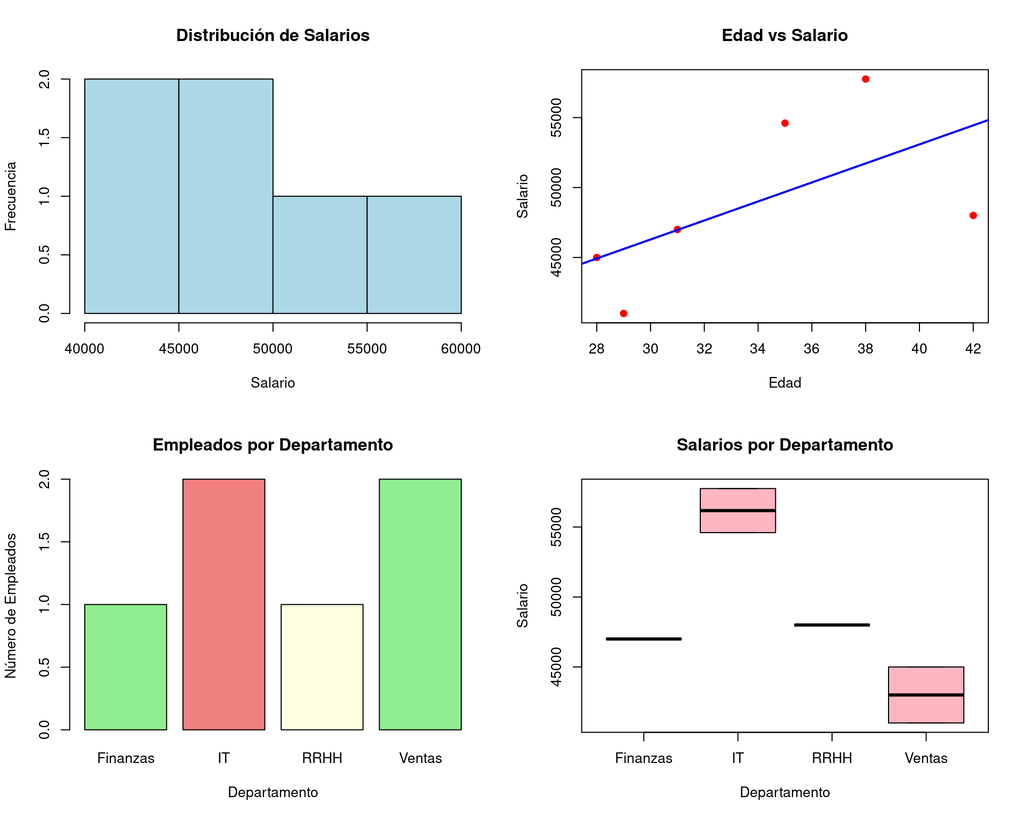

```r
# Configurar para mostrar múltiples gráficos
par(mfrow = c(2, 2))

# Histograma
hist(empleados$salario,
     main = "Distribución de Salarios",
     xlab = "Salario",
     ylab = "Frecuencia",
     col = "lightblue",
     border = "black")

# Diagrama de dispersión
plot(empleados$edad, empleados$salario,
     main = "Edad vs Salario",
     xlab = "Edad",
     ylab = "Salario",
     col = "red",
     pch = 19)

# Agregar línea de tendencia
abline(lm(salario ~ edad, data = empleados), col = "blue", lwd = 2)

# Gráfico de barras
barplot(table(empleados$departamento),
        main = "Empleados por Departamento",
        xlab = "Departamento",
        ylab = "Número de Empleados",
        col = c("lightgreen", "lightcoral", "lightyellow"))

# Boxplot
boxplot(salario ~ departamento,
        data = empleados,
        main = "Salarios por Departamento",
        xlab = "Departamento",
        ylab = "Salario",
        col = "lightpink")
```

```r
# Restaurar configuración de gráficos
par(mfrow = c(1, 1))
```

# 10 Trabajo con Fechas y Strings

## 10.1 Fechas básicas

```r
# Trabajar con fechas
fecha_actual <- Sys.Date()
print(paste("Fecha actual:", fecha_actual))
```

```
## [1] "Fecha actual: 2025-11-13"
```

```r
# Crear fechas
fechas <- as.Date(c("2023-01-01", "2023-06-15", "2023-12-31"))
print("Fechas creadas:")
```

```
## [1] "Fechas creadas:"
```

```r
print(fechas)
```

```
## [1] "2023-01-01" "2023-06-15" "2023-12-31"
```

```r
# Operaciones con fechas
diferencia <- fecha_actual - fechas[1]
print(paste("Días desde el 1 de enero 2023:", diferencia))
```

```
## [1] "Días desde el 1 de enero 2023: 1047"
```

```r
# Formato de fechas
print("Diferentes formatos de fecha:")
```

```
## [1] "Diferentes formatos de fecha:"
```

```r
print(format(fecha_actual, "%d/%m/%Y"))
```

```
## [1] "13/11/2025"
```

```r
print(format(fecha_actual, "%B %d, %Y"))
```

```
## [1] "November 13, 2025"
```

```r
print(format(fecha_actual, "%A"))
```

```
## [1] "Thursday"
```

## 10.2 Manipulación de strings

```r
# Operaciones básicas con strings
nombres_completos <- c("Ana García López", "Carlos Martín Silva", "María Fernández")

print("Nombres originales:")
```

```
## [1] "Nombres originales:"
```

```r
print(nombres_completos)
```

```
## [1] "Ana García López"    "Carlos Martín Silva" "María Fernández"
```

```r
# Longitud de strings
print("Longitud de cada nombre:")
```

```
## [1] "Longitud de cada nombre:"
```

```r
print(nchar(nombres_completos))
```

```
## [1] 16 19 15
```

```r
# Convertir a mayúsculas/minúsculas
print("En mayúsculas:")
```

```
## [1] "En mayúsculas:"
```

```r
print(toupper(nombres_completos))
```

```
## [1] "ANA GARCÍA LÓPEZ"    "CARLOS MARTÍN SILVA" "MARÍA FERNÁNDEZ"
```

```r
print("En minúsculas:")
```

```
## [1] "En minúsculas:"
```

```r
print(tolower(nombres_completos))
```

```
## [1] "ana garcía lópez"    "carlos martín silva" "maría fernández"
```

```r
# Extraer partes de strings
print("Primeros nombres (primeros 10 caracteres):")
```

```
## [1] "Primeros nombres (primeros 10 caracteres):"
```

```r
print(substr(nombres_completos, 1, 10))
```

```
## [1] "Ana García" "Carlos Mar" "María Fern"
```

```r
# Dividir strings
print("Dividir nombres:")
```

```
## [1] "Dividir nombres:"
```

```r
nombres_divididos <- strsplit(nombres_completos[1], " ")
print(nombres_divididos)
```

```
## [[1]]
## [1] "Ana"    "García" "López"
```

```r
# Pegar strings
nuevo_nombre <- paste("Dr.", nombres_completos[1])
print(paste("Nombre con título:", nuevo_nombre))
```

```
## [1] "Nombre con título: Dr. Ana García López"
```

# 11 Lectura y Escritura de Archivos

```r
# Escribir datos a CSV
write.csv(empleados, "empleados.csv", row.names = FALSE)
print("Archivo empleados.csv creado")

rm(empleados)

# Leer datos de CSV
empleados_leidos <- read.csv("empleados.csv", stringsAsFactors = FALSE)
print("Datos leídos desde CSV:")
head(empleados_leidos)

empleados = empleados_leidos

# Escribir a archivo de texto
writeLines(c("Reporte de empleados",
             paste("Total empleados:", nrow(empleados)),
             paste("Salario promedio:", round(mean(empleados$salario), 2))),
           "reporte.txt")

# Leer archivo de texto
reporte <- readLines("reporte.txt")
print("Contenido del reporte:")
print(reporte)
```

[output not shown]

# 12 Análisis Final: Proyecto Integrador

Vamos a combinar todo lo aprendido en un análisis completo.

```r
# Crear un dataset más complejo para el análisis final
set.seed(789)
n_empleados <- 50

empleados_completo <- data.frame(
  id = 1:n_empleados,
  nombre = paste("Empleado", 1:n_empleados),
  departamento = sample(c("Ventas", "IT", "RRHH", "Finanzas", "Marketing"), n_empleados, replace = TRUE),
  edad = sample(22:65, n_empleados, replace = TRUE),
  años_empresa = sample(1:20, n_empleados, replace = TRUE),
  salario_base = sample(35000:80000, n_empleados, replace = TRUE),
  activo = sample(c(TRUE, FALSE), n_empleados, replace = TRUE, prob = c(0.9, 0.1))
)

# Agregar columnas calculadas
empleados_completo$salario_total <- empleados_completo$salario_base +
  (empleados_completo$años_empresa * 1000)  # Bonus por antigüedad

empleados_completo$categoria_edad <- ifelse(empleados_completo$edad < 30, "Joven",
                                   ifelse(empleados_completo$edad < 50, "Medio", "Senior"))

# Análisis completo
print("=== ANÁLISIS COMPLETO DE EMPLEADOS ===")
```

```
## [1] "=== ANÁLISIS COMPLETO DE EMPLEADOS ==="
```

```r
# 1. Estadísticas generales
cat("\n1. ESTADÍSTICAS GENERALES\n")
```

```
##
## 1. ESTADÍSTICAS GENERALES
```

```r
cat("Total de empleados:", nrow(empleados_completo), "\n")
```

```
## Total de empleados: 50
```

```r
cat("Empleados activos:", sum(empleados_completo$activo), "\n")
```

```
## Empleados activos: 44
```

```r
cat("Salario promedio:", round(mean(empleados_completo$salario_total), 2), "\n")
```

```
## Salario promedio: 67769.64
```

```r
cat("Edad promedio:", round(mean(empleados_completo$edad), 2), "\n")
```

```
## Edad promedio: 44.86
```

```r
# 2. Análisis por departamento
cat("\n2. ANÁLISIS POR DEPARTAMENTO\n")
```

```
##
## 2. ANÁLISIS POR DEPARTAMENTO
```

```r
for (dept in unique(empleados_completo$departamento)) {
  dept_data <- empleados_completo[empleados_completo$departamento == dept, ]
  cat("\nDepartamento:", dept, "\n")
  cat("  Empleados:", nrow(dept_data), "\n")
  cat("  Salario promedio:", round(mean(dept_data$salario_total), 2), "\n")
  cat("  Edad promedio:", round(mean(dept_data$edad), 2), "\n")
  cat("  Años promedio en empresa:", round(mean(dept_data$años_empresa), 2), "\n")
}
```

```
##
## Departamento: Marketing
##   Empleados: 10
##   Salario promedio: 73759
##   Edad promedio: 42.5
##   Años promedio en empresa: 10.3
##
## Departamento: Finanzas
##   Empleados: 10
##   Salario promedio: 64180.2
##   Edad promedio: 44.3
##   Años promedio en empresa: 11.6
##
## Departamento: IT
##   Empleados: 16
##   Salario promedio: 71028.94
##   Edad promedio: 45.5
##   Años promedio en empresa: 12.56
##
## Departamento: RRHH
##   Empleados: 9
##   Salario promedio: 65375
##   Edad promedio: 45.33
##   Años promedio en empresa: 8.78
##
## Departamento: Ventas
##   Empleados: 5
##   Salario promedio: 56850.4
##   Edad promedio: 47.8
##   Años promedio en empresa: 9.2
```

```r
# 3. Top performers
cat("\n3. TOP PERFORMERS\n")
```

```
##
## 3. TOP PERFORMERS
```

```r
top_salarios <- empleados_completo[order(empleados_completo$salario_total, decreasing = TRUE), ][1:5, ]
print(top_salarios[, c("nombre", "departamento", "salario_total")])
```

```
##         nombre departamento salario_total
## 27 Empleado 27    Marketing         96092
## 7   Empleado 7    Marketing         89185
## 34 Empleado 34           IT         89076
## 16 Empleado 16    Marketing         85871
## 9   Empleado 9         RRHH         85113
```

```r
# 4. Análisis de correlaciones
cat("\n4. CORRELACIÓN EDAD-SALARIO\n")
```

```
##
## 4. CORRELACIÓN EDAD-SALARIO
```

```r
correlacion <- cor(empleados_completo$edad, empleados_completo$salario_total)
cat("Correlación edad-salario:", round(correlacion, 3), "\n")
```

```
## Correlación edad-salario: -0.142
```

```r
# 5. Resumen final
cat("\n5. INSIGHTS PRINCIPALES\n")
```

```
##
## 5. INSIGHTS PRINCIPALES
```

```r
dept_mejor_pagado <- names(sort(tapply(empleados_completo$salario_total,
                                      empleados_completo$departamento, mean),
                               decreasing = TRUE))[1]
cat("Departamento mejor pagado:", dept_mejor_pagado, "\n")
```

```
## Departamento mejor pagado: Marketing
```

```r
empleado_mas_antiguo <- empleados_completo[which.max(empleados_completo$años_empresa), ]
cat("Empleado más antiguo:", empleado_mas_antiguo$nombre,
    "con", empleado_mas_antiguo$años_empresa, "años\n")
```

```
## Empleado más antiguo: Empleado 20 con 20 años
```

# 13 Conclusión

¡Felicitaciones! Has completado el tutorial básico de R. Has aprendido los fundamentos esenciales

## 13.1 Conceptos cubiertos:

- **Tipos de datos**: vectores, listas, data frames
- **Manipulación de datos**: indexación, filtrado, agregación
- **Estadísticas básicas**: media, mediana, desviación estándar
- **Control de flujo**: if/else, bucles for y while
- **Funciones**: creación y uso de funciones personalizadas
- **Gráficos básicos**: histogramas, scatter plots, boxplots
- **Trabajo con strings y fechas**
- **Funciones apply**: apply, lapply, sapply, tapply